# OSCBOP notes

Don Boyd

August 01, 2014

# Possible approaches

Goal: Allocate as much of the federal budget as is practical  revenue and spending  to each of the individual 50 states, using “reasonable” methodologies.

Two possible approaches:

1. Foot the numbers to the federal budget  the formal data on receipts and disbursements, and the official budget deficit. Where data allow (rare), use actual information on how each component of the budget is distributed to individual states. In other cases “allocate” spending to individual states based on reasonable proxies. (NOTE: When I use the term “federal budget” I am referring to a data source and a way of categorizing data. The term “budget” here does NOT mean that the numbers are budgeted or projected.)
2. Use “disembodied” numbers from different data sources for major elements of the federal budget, and dont worry too much if they do not add up to the federal budget precisely.

The attraction of the former is it allows us to get at the balance of payments concept but it forces us to come up with proxies to allocate the budget. The advantage of the latter is that it requires fewer assumptions, but then we dont foot to the full budget. I believe the first approach is best for our purposes as long as we think we have reasonable proxies  an issue we currently are exploring.

## Authority, obligations or outlays?

Per the 1999 Moynihan report (p.109), “The dollar amounts reported by the Census Bureau in the CFFR report can represent either actual expenditures or obligations. As a general guide, the grants and procurement data in the CFFR report represent obligated funds, while the salaries, wages and direct payments show actual expenditures.”"

## How the Moynihan report addressed this issue

Moynihan/KSG appear to have used a variant of #2: As far as I can tell, they added up all spending in CFFR, and treated that as the totality of federal spending, and then allocated a like amount of taxes (to force a balanced budget). That worked for them, I believe, because the CFFR accounted for about “four fifths” of federal outlays, per the 1999 fisc report. Per the Moynihan report:

- The calculations of Federal expenditures allocated to states are based on the reconciliation of two sources of data, the Consolidated Federal Funds Report, published by the Census Bureau, and the Budget of the United States Government, published by the Office of Management and Budget. While the Census Bureau does attempt to reconcile their data with the Federal budget, the two are not completely comparable. Over the past seven years, the Census measure of expenditures distributed domestically has accounted for about four fifths of total Federal outlays published by the Office of Management and Budget. Some areas of the budget, like foreign aid and some military spending, are spent overseas, so are not included in the Census data. No consistent methodology has been established to distribute other areas of spending such as net interest, deposit insurance or undistributed (by program) offsetting receipts. Finally, the amounts shown in the report for defense expenditures include all spending by the Department of Defense plus Department of Energy spending on defense-related activities and military retirement, disability payments, and other veterans benefits. (1999 Fisc Report, p.111)

## What Pew and NPP are doing

The National Priorities Project, and Pew, in their respective projects, are using the second approach. That is, they are not trying to add up to the full federal budget. This makes sense for their purposes because they are not comparing federal revenue to federal spending, and are not professing to allocate the entire federal budget to the 50 states.

# Federal budget overview

FFY 2013 ended Sept 30, 2013 and we have reasonably complete data, so this is the year to use.

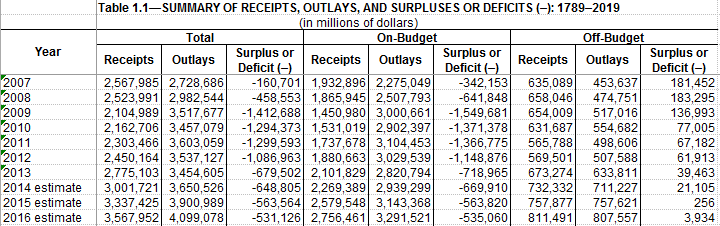

Total spending in 2013 on this basis was $3.455 trillion.

When we look at USASpending we appear to come up about $450-500 billion short. The table below shows $2.5 trillion of spending, plus another $467 billion we know about from personnel data. The two together are about 87% of federal outlays.

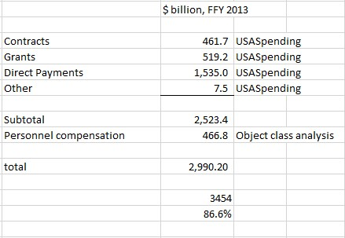

# Grants analysis

## Conclusions so far

We have two main sources of grants data that are easily allocable to states, USASpending and FFIS, and they differ significantly in their totals and in the amounts for specific grants. (We also may have some agency sources and other sources for specific large grants.) Fortunately, (a) we can isolate those differences and I have begun to do that, and (b) preliminary indications are that the largest differences are isolated in a relatively small number of large grants.

I think the main tasks ahead are to:

1. Examine the largest differences. I can provide lists that facilitate this.
2. Make a judgment about which source is best for these specific large grants, and use that source to allocate these large grants.
3. Make a judgment about which source is likely to be best for the remaining grants for which we have data from both sources, and use that source (FFIS or USASpending) for remaining sources in common.
4. Use USASpending for the sources for which we only have USASpending.

We can computerize the allocation of grants to states so that the work is not labor intensive. However, step #2 above is likely to be labor intensive.

## USASpending grants

Total USASpending grants in FFY 2013 were $519.215 billion

### USASpending grants by geography

```
## USASpending grants in billions, FFY 2013, by state/DC or not state/DC
```

```
##
##
## |stateorDC | totgrantsb|
## |:---------|----------:|
## |FALSE     |       7.41|
## | TRUE     |     511.81|
```

```
## USASpending grants in billions, FFY 2013, by state (+DC)
```

```
##
##
## |recipient_state_code |stname               | totgrantsb|
## |:--------------------|:--------------------|----------:|
## |CA                   |California           |     66.861|
## |NY                   |New York             |     53.255|
## |TX                   |Texas                |     35.186|
## |PA                   |Pennsylvania         |     21.909|
## |FL                   |Florida              |     19.084|
## |IL                   |Illinois             |     17.627|
## |MI                   |Michigan             |     16.517|
## |OH                   |Ohio                 |     16.205|
## |MA                   |Massachusetts        |     15.439|
## |NJ                   |New Jersey           |     15.380|
## |NC                   |North Carolina       |     14.704|
## |GA                   |Georgia              |     11.635|
## |MO                   |Missouri             |     11.566|
## |WA                   |Washington           |     10.633|
## |MD                   |Maryland             |     10.470|
## |IN                   |Indiana              |      9.436|
## |TN                   |Tennessee            |      9.376|
## |VA                   |Virginia             |      9.266|
## |AZ                   |Arizona              |      9.068|
## |MN                   |Minnesota            |      9.059|
## |LA                   |Louisiana            |      9.021|
## |DC                   |District of Columbia |      8.793|
## |WI                   |Wisconsin            |      8.626|
## |CT                   |Connecticut          |      7.113|
## |CO                   |Colorado             |      7.080|
## |KY                   |Kentucky             |      6.600|
## |OK                   |Oklahoma             |      6.401|
## |AL                   |Alabama              |      6.170|
## |SC                   |South Carolina       |      5.689|
## |AR                   |Arkansas             |      5.518|
## |IA                   |Iowa                 |      4.782|
## |NM                   |New Mexico           |      4.682|
## |OR                   |Oregon               |      4.594|
## |MS                   |Mississippi          |      4.161|
## |WV                   |West Virginia        |      3.991|
## |UT                   |Utah                 |      3.505|
## |ME                   |Maine                |      3.187|
## |HI                   |Hawaii               |      2.884|
## |NV                   |Nevada               |      2.719|
## |AK                   |Alaska               |      2.647|
## |NE                   |Nebraska             |      2.539|
## |RI                   |Rhode Island         |      2.424|
## |ID                   |Idaho                |      2.377|
## |MT                   |Montana              |      2.261|
## |VT                   |Vermont              |      1.895|
## |KS                   |Kansas               |      1.888|
## |DE                   |Delaware             |      1.737|
## |NH                   |New Hampshire        |      1.648|
## |ND                   |North Dakota         |      1.565|
## |SD                   |South Dakota         |      1.555|
## |WY                   |Wyoming              |      1.078|
```

```
## USASpending grants in billions, FFY 2013, for non-state geographies
```

```
##
##
## |recipient_state_code |stname         | totgrantsb|
## |:--------------------|:--------------|----------:|
## |                     |NA             |      5.101|
## |PR                   |Puerto Rico    |      1.782|
## |VI                   |Virgin Islands |      0.170|
## |GU                   |NA             |      0.145|
## |AS                   |NA             |      0.105|
## |MP                   |NA             |      0.084|
## |FM                   |NA             |      0.013|
## |PW                   |NA             |      0.005|
## |MH                   |NA             |      0.005|
```

### USASpending grants by program

USASpending grants in billions, FFY 2013, top 50 programs

| cfda_program_num | cfda_program_title | totgrantsb | cumsum | pct | cumpct |
| --- | --- | --- | --- | --- | --- |
| 93.778 | Medical Assistance Program | 241.72 | 241.7 | 46.56 | 46.56 |
| 20.205 | Highway Planning and Construction | 39.35 | 281.1 | 7.58 | 54.13 |
| 10.555 | National School Lunch Program | 17.43 | 298.5 | 3.36 | 57.49 |
| 93.558 | Temporary Assistance for Needy Families | 17.21 | 315.7 | 3.32 | 60.81 |
| 98.001 | USAID Foreign Assistance for Programs Overseas | 7.75 | 323.5 | 1.49 | 62.30 |
| 93.600 | Head Start | 7.36 | 330.8 | 1.42 | 63.72 |
| 93.767 | Children’s Health Insurance Program | 6.64 | 337.5 | 1.28 | 65.00 |
| 10.557 | Special Supplemental Nutrition Program for Women, Infants, and Children | 6.50 | 344.0 | 1.25 | 66.25 |
| 93.596 | Child Care Mandatory and Matching Funds of the Child Care and Development Fund | 5.06 | 349.0 | 0.97 | 67.22 |
| 20.507 | Federal Transit_Formula Grants | 5.04 | 354.1 | 0.97 | 68.20 |
| 97.036 | Disaster Grants - Public Assistance (Presidentially Declared Disasters) | 5.02 | 359.1 | 0.97 | 69.16 |
| 14.850 | Public and Indian Housing | 4.75 | 363.9 | 0.92 | 70.08 |
| 93.658 | Foster Care_Title IV-E | 3.80 | 367.6 | 0.73 | 70.81 |
| 10.561 | State Administrative Matching Grants for the Supplemental Nutrition Assistance Program | 3.79 | 371.4 | 0.73 | 71.54 |
| 17.225 | Unemployment Insurance | 3.72 | 375.2 | 0.72 | 72.26 |
| 20.500 | Federal Transit_Capital Investment Grants | 3.59 | 378.8 | 0.69 | 72.95 |
| 14.218 | Community Development Block Grants/Entitlement Grants | 3.52 | 382.3 | 0.68 | 73.62 |
| 93.568 | Low-Income Home Energy Assistance | 3.12 | 385.4 | 0.60 | 74.23 |
| 14.872 | Public Housing Capital Fund | 3.07 | 388.5 | 0.59 | 74.82 |
| 84.126 | Rehabilitation Services_Vocational Rehabilitation Grants to States | 2.93 | 391.4 | 0.56 | 75.38 |
| 84.010 | Title I Grants to Local Educational Agencies | 2.88 | 394.3 | 0.55 | 75.93 |
| 20.106 | Airport Improvement Program | 2.88 | 397.1 | 0.55 | 76.49 |
| 93.527 | Affordable Care Act (ACA) Grants for New and Expanded Services under the Health Center Program | 2.64 | 399.8 | 0.51 | 77.00 |
| 93.855 | Allergy, Immunology and Transplantation Research | 2.49 | 402.3 | 0.48 | 77.48 |
| 97.109 | Disaster Housing Assistance Grant | 2.23 | 404.5 | 0.43 | 77.91 |
| 93.563 | Child Support Enforcement | 2.18 | 406.7 | 0.42 | 78.33 |
| 93.859 | Biomedical Research and Research Training | 2.12 | 408.8 | 0.41 | 78.74 |
| 93.659 | Adoption Assistance | 2.10 | 410.9 | 0.40 | 79.14 |
| 14.269 | Hurricane Sandy Community Development Block Grant Disaster Recovery Grants (CDBG-DR) | 2.09 | 413.0 | 0.40 | 79.54 |
| 93.525 | State Planning and Establishment Grants for the Affordable Care Act (ACA)Â¿s Exchanges | 2.04 | 415.0 | 0.39 | 79.93 |
| 12.401 | National Guard Military Operations and Maintenance (O&M) Projects | 1.66 | 416.7 | 0.32 | 80.25 |
| 14.228 | Community Development Block Grants/State’s program and Non-Entitlement Grants in Hawaii | 1.62 | 418.3 | 0.31 | 80.57 |
| 84.027 | Special Education_Grants to States | 1.62 | 419.9 | 0.31 | 80.88 |
| 93.959 | Block Grants for Prevention and Treatment of Substance Abuse | 1.60 | 421.5 | 0.31 | 81.19 |
| 14.239 | Home Investment Partnerships Program | 1.59 | 423.1 | 0.31 | 81.49 |
| 14.267 | Continuum of Care Program | 1.54 | 424.7 | 0.30 | 81.79 |
| 93.847 | Diabetes, Digestive, and Kidney Diseases Extramural Research | 1.51 | 426.2 | 0.29 | 82.08 |
| 93.837 | Cardiovascular Diseases Research | 1.50 | 427.7 | 0.29 | 82.37 |
| 93.667 | Social Services Block Grant | 1.40 | 429.1 | 0.27 | 82.64 |
| 93.067 | Global AIDS | 1.36 | 430.4 | 0.26 | 82.90 |
| 66.458 | Capitalization Grants for Clean Water State Revolving Funds | 1.36 | 431.8 | 0.26 | 83.17 |
| 47.049 | Mathematical and Physical Sciences | 1.34 | 433.1 | 0.26 | 83.42 |
| 93.853 | Extramural Research Programs in the Neurosciences and Neurological Disorders | 1.26 | 434.4 | 0.24 | 83.67 |
| 93.917 | HIV Care Formula Grants | 1.23 | 435.6 | 0.24 | 83.90 |
| 84.041 | Impact Aid | 1.21 | 436.9 | 0.23 | 84.14 |
| 93.045 | Special Programs for the Aging_Title III, Part C_Nutrition Services | 1.13 | 438.0 | 0.22 | 84.35 |
| 14.867 | Indian Housing Block Grants | 1.11 | 439.1 | 0.21 | 84.57 |
| 93.242 | Mental Health Research Grants | 1.11 | 440.2 | 0.21 | 84.78 |
| 47.076 | Education and Human Resources | 1.10 | 441.3 | 0.21 | 84.99 |
| 84.287 | Twenty-First Century Community Learning Centers | 1.08 | 442.4 | 0.21 | 85.20 |

### USASpending grants by recipient type

USASpending grants in billions, FFY 2013, by recipient type

| recipient_type | totgrantsb |
| --- | --- |
| 00: State government | 413.39 |
| 01: County government | 4.21 |
| 02: City or township government | 17.46 |
| 04: Special district government | 9.80 |
| 05: Independent school district | 2.16 |
| 06: State controlled institution of higher education | 20.59 |
| 11: Indian tribe | 2.30 |
| 12: Other nonprofit | 26.35 |
| 20: Private higher education | 8.70 |
| 21: Individual | 0.13 |
| 22: Profit organization | 1.95 |
| 23: Small business | 2.34 |
| 25: All other | 9.83 |

## FFIS grants

```
##
## FFIS grants in billions, by federal fiscal year
```

```
## Source: local data frame [8 x 2]
##
##   fyear value
## 1  2006 429.2
## 2  2007 448.7
## 3  2008 475.9
## 4  2009 530.4
## 5  2010 576.4
## 6  2011 600.3
## 7  2012 602.0
## 8  2013 614.2
```

```
##
## FFIS grants for 2013 in billions, by states vs. other geographies
```

```
## Source: local data frame [2 x 2]
##
##   state %in% nonstateDC  value
## 1                 FALSE 590.99
## 2                  TRUE  23.21
```

```
##
## FFIS grants for 2013 in billions, by geography
```

```
## Source: local data frame [58 x 2]
##
##                       state    value
## 1                California 76.66297
## 2                  New York 54.51324
## 3                     Texas 43.09644
## 4                   Florida 29.60352
## 5              Pennsylvania 23.97240
## 6                      Ohio 22.63127
## 7                  Illinois 21.85960
## 8                  Michigan 19.11802
## 9            North Carolina 17.06557
## 10                  Georgia 16.38504
## 11              Unallocated 15.09669
## 12                Tennessee 13.89828
```

[output cut: 46 more lines]

```
##
## FFIS grants for 2013 in billions, states & DC only, by concept used to measure spending
```

```
## OB=Obligations, BA=Budget Authority, AP=Apportionment
```

```
## Source: local data frame [3 x 2]
##
##   xtype2013  value
## 1        OB 419.64
## 2        BA 121.34
## 3        AP  50.01
```

```
##
## FFIS grants for 2013 in billions, states & DC only, by major grant category, where amount > $2b
```

```
## Source: local data frame [35 x 3]
## Groups: cfda
##
##              cfda                                                   program   value
## 1          93.778                                Medicaid - Vendor Payments 259.276
## 2          10.551 Supplemental Nutrition Assistance Program (SNAP) Benefits  75.891
## 3          84.063                                               Pell Grants  31.409
## 4          20.205               FHWA - National Highway Performance Program  22.128
## 5          93.558                   Temporary Assistance For Needy Families  16.307
## 6          84.010              Comp Ed (Title I) - Local Education Agencies  13.165
## 7          93.778                                 Medicaid - Administration  12.138
## 8          10.555                            Child Nutrition - School Lunch  10.900
## 9          84.027                       Special Education Basic State Grant  10.709
## 10         20.205                     FHWA - Surface Transportation Program  10.192
## 11         93.767                       Children's Health Insurance Program   8.800
```

[output cut: 24 more lines]

## Comparison of USASpending grants and FFIS grants

### State shares of total

```
##
## FFIS grants for 2013 in billions, states & DC only, with US totals, and with state shares
```

```
##
##
## |stname               |  value| pctshare|
## |:--------------------|------:|--------:|
## | US Total            | 590.99|   100.00|
## |California           |  76.66|    12.97|
## |New York             |  54.51|     9.22|
## |Texas                |  43.10|     7.29|
## |Florida              |  29.60|     5.01|
## |Pennsylvania         |  23.97|     4.06|
## |Ohio                 |  22.63|     3.83|
## |Illinois             |  21.86|     3.70|
## |Michigan             |  19.12|     3.23|
## |North Carolina       |  17.07|     2.89|
## |Georgia              |  16.39|     2.77|
## |Tennessee            |  13.90|     2.35|
## |New Jersey           |  13.70|     2.32|
## |Massachusetts        |  13.65|     2.31|
## |Arizona              |  13.05|     2.21|
## |Indiana              |  11.93|     2.02|
## |Missouri             |  11.53|     1.95|
## |Louisiana            |  10.47|     1.77|
## |Virginia             |  10.31|     1.75|
## |Washington           |  10.25|     1.73|
## |Wisconsin            |   9.84|     1.66|
## |Minnesota            |   9.37|     1.59|
## |Alabama              |   9.19|     1.55|
## |Maryland             |   9.13|     1.54|
## |Kentucky             |   9.09|     1.54|
## |South Carolina       |   8.02|     1.36|
## |Oregon               |   7.96|     1.35|
## |Mississippi          |   7.63|     1.29|
## |Oklahoma             |   7.08|     1.20|
## |Colorado             |   7.02|     1.19|
## |Connecticut          |   6.85|     1.16|
## |Arkansas             |   6.32|     1.07|
## |New Mexico           |   5.74|     0.97|
## |Iowa                 |   5.54|     0.94|
## |West Virginia        |   4.68|     0.79|
## |Utah                 |   4.09|     0.69|
## |Kansas               |   4.02|     0.68|
## |Nevada               |   3.31|     0.56|
## |District of Columbia |   3.11|     0.53|
## |Maine                |   3.00|     0.51|
## |Idaho                |   2.97|     0.50|
## |Nebraska             |   2.81|     0.47|
## |Hawaii               |   2.80|     0.47|
## |Alaska               |   2.67|     0.45|
## |Rhode Island         |   2.49|     0.42|
## |Montana              |   2.18|     0.37|
## |Wyoming              |   2.04|     0.35|
## |Delaware             |   1.96|     0.33|
## |Vermont              |   1.72|     0.29|
## |New Hampshire        |   1.63|     0.28|
## |South Dakota         |   1.60|     0.27|
## |North Dakota         |   1.44|     0.24|
```

```
##
## USASpending grants for 2013 in billions, states & DC only, with US totals, and with state shares
```

```
##
##
## |stname               |  value| pctshare|
## |:--------------------|------:|--------:|
## | US Total            | 511.80|   100.00|
## |California           |  66.86|    13.06|
## |New York             |  53.26|    10.41|
## |Texas                |  35.19|     6.87|
## |Pennsylvania         |  21.91|     4.28|
## |Florida              |  19.08|     3.73|
## |Illinois             |  17.63|     3.44|
## |Michigan             |  16.52|     3.23|
## |Ohio                 |  16.20|     3.17|
## |Massachusetts        |  15.44|     3.02|
## |New Jersey           |  15.38|     3.01|
## |North Carolina       |  14.70|     2.87|
## |Georgia              |  11.64|     2.27|
## |Missouri             |  11.57|     2.26|
## |Washington           |  10.63|     2.08|
## |Maryland             |  10.47|     2.05|
## |Indiana              |   9.44|     1.84|
## |Tennessee            |   9.38|     1.83|
## |Virginia             |   9.27|     1.81|
## |Arizona              |   9.07|     1.77|
## |Minnesota            |   9.06|     1.77|
## |Louisiana            |   9.02|     1.76|
## |District of Columbia |   8.79|     1.72|
## |Wisconsin            |   8.63|     1.69|
## |Connecticut          |   7.11|     1.39|
## |Colorado             |   7.08|     1.38|
## |Kentucky             |   6.60|     1.29|
## |Oklahoma             |   6.40|     1.25|
## |Alabama              |   6.17|     1.21|
## |South Carolina       |   5.69|     1.11|
## |Arkansas             |   5.52|     1.08|
## |Iowa                 |   4.78|     0.93|
## |New Mexico           |   4.68|     0.91|
## |Oregon               |   4.59|     0.90|
## |Mississippi          |   4.16|     0.81|
## |West Virginia        |   3.99|     0.78|
## |Utah                 |   3.50|     0.68|
## |Maine                |   3.19|     0.62|
## |Hawaii               |   2.88|     0.56|
## |Nevada               |   2.72|     0.53|
## |Alaska               |   2.65|     0.52|
## |Nebraska             |   2.54|     0.50|
## |Rhode Island         |   2.42|     0.47|
## |Idaho                |   2.38|     0.46|
## |Montana              |   2.26|     0.44|
## |Vermont              |   1.89|     0.37|
## |Kansas               |   1.89|     0.37|
## |Delaware             |   1.74|     0.34|
## |New Hampshire        |   1.65|     0.32|
## |North Dakota         |   1.57|     0.31|
## |South Dakota         |   1.56|     0.30|
## |Wyoming              |   1.08|     0.21|
```

```
##
## Scatterplot of state shares of allocated grants, 2013, FFIS vs. USASpending
```

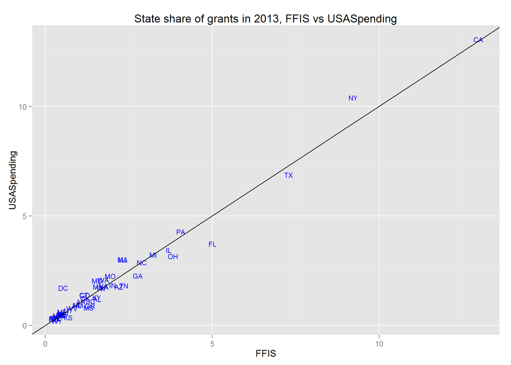

```
##
## Scatterplot of state shares of allocated grants, 2013, FFIS vs. USASpending
##     Excluding CA, NY, and TX
```

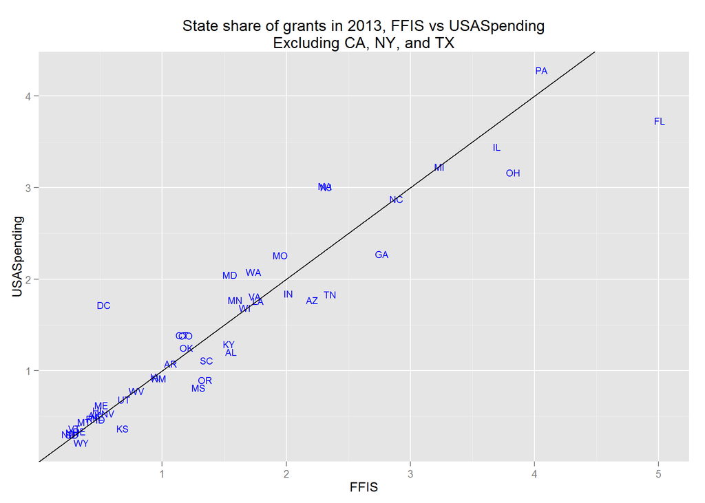

### 50 largest differences, considering all grants

| cfda | usasname | ffis | usas | maxdiff |
| --- | --- | --- | --- | --- |
| 10.551 | NA | 76.07 | NA | 76.07 |
| 84.063 | NA | 32.40 | NA | 32.40 |
| 93.778 | Medical Assistance Program | 272.53 | 241.72 | 30.81 |
| 84.010 | Title I Grants to Local Educational Agencies | 13.76 | 2.88 | 10.88 |
| 93.767 | Children’s Health Insurance Program | 17.41 | 6.64 | 10.76 |
| 84.027 | Special Education_Grants to States | 10.97 | 1.62 | 9.36 |
| 98.001 | USAID Foreign Assistance for Programs Overseas | NA | 7.75 | 7.75 |
| 97.036 | Disaster Grants - Public Assistance (Presidentially Declared Disasters) | NA | 5.02 | 5.02 |
| 10.555 | National School Lunch Program | 12.68 | 17.43 | 4.75 |
| 93.268 | Immunization Cooperative Agreements | 4.08 | 0.31 | 3.77 |
| 10.553 | NA | 3.51 | NA | 3.51 |
| 93.224 | Consolidated Health Centers (Community Health Centers, Migrant Health Centers, Health Care for the Homeless, Public Housing Primary Care, and School Based Health Centers) | 2.95 | 0.00 | 2.95 |
| 93.224 | Consolidated Health Centers (Community Health Centers, Migrant Health Centers, Health Care for the Homeless, and Public Housing Primary Care) | 2.95 | 0.01 | 2.94 |
| 93.527 | Affordable Care Act (ACA) Grants for New and Expanded Services under the Health Center Program | NA | 2.64 | 2.64 |
| 93.855 | Allergy, Immunology and Transplantation Research | NA | 2.49 | 2.49 |
| 10.558 | Child and Adult Care Food Program | 2.95 | 0.59 | 2.36 |
| 97.109 | Disaster Housing Assistance Grant | NA | 2.23 | 2.23 |
| 93.575 | Child Care and Development Block Grant | 2.21 | 0.00 | 2.20 |
| 93.596 | Child Care Mandatory and Matching Funds of the Child Care and Development Fund | 2.92 | 5.06 | 2.14 |
| 93.859 | Biomedical Research and Research Training | NA | 2.12 | 2.12 |
| 14.269 | Hurricane Sandy Community Development Block Grant Disaster Recovery Grants (CDBG-DR) | NA | 2.09 | 2.09 |
| 93.563 | Child Support Enforcement | 4.23 | 2.18 | 2.05 |
| 93.525 | State Planning and Establishment Grants for the Affordable Care Act (ACA)Â¿s Exchanges | NA | 2.04 | 2.04 |
| 15.437, 15.430 | NA | 2.00 | NA | 2.00 |
| 10.566 | NA | 1.87 | NA | 1.87 |
| 20.205 | Highway Planning and Construction | 37.56 | 39.35 | 1.79 |
| 84.367 | Improving Teacher Quality State Grants | 2.34 | 0.62 | 1.72 |
| 12.401 | National Guard Military Operations and Maintenance (O&M) Projects | NA | 1.66 | 1.66 |
| 14.267 | Continuum of Care Program | NA | 1.54 | 1.54 |
| 93.847 | Diabetes, Digestive, and Kidney Diseases Extramural Research | NA | 1.51 | 1.51 |
| 93.837 | Cardiovascular Diseases Research | NA | 1.50 | 1.50 |
| 20.525 | State of Good Repair Grants Program | 2.13 | 0.67 | 1.46 |
| 14.218 | Community Development Block Grants/Entitlement Grants | 2.16 | 3.52 | 1.36 |
| 93.067 | Global AIDS | NA | 1.36 | 1.36 |
| 47.049 | Mathematical and Physical Sciences | NA | 1.34 | 1.34 |
| 20.500 | Federal Transit_Capital Investment Grants | 2.28 | 3.59 | 1.31 |
| 14.872 | Public Housing Capital Fund | 1.78 | 3.07 | 1.29 |
| 93.853 | Extramural Research Programs in the Neurosciences and Neurological Disorders | NA | 1.26 | 1.26 |
| 14.867 | Indian Housing Block Grants | NA | 1.11 | 1.11 |
| 93.242 | Mental Health Research Grants | NA | 1.11 | 1.11 |
| 47.076 | Education and Human Resources | NA | 1.10 | 1.10 |
| 81.049 | Office of Science Financial Assistance Program | NA | 0.99 | 0.99 |
| 47.050 | Geosciences | NA | 0.97 | 0.97 |
| 84.033 | NA | 0.93 | NA | 0.93 |
| 97.037 | DISASTER HOUSING PROGRAM | NA | -0.92 | 0.92 |
| 93.074 | Hospital Preparedness Program (HPP) and Public Health Emergency Preparedness (PHEP) Aligned Cooperative Agreements | NA | 0.91 | 0.91 |
| 93.865 | Child Health and Human Development Extramural Research | NA | 0.90 | 0.90 |
| 64.015 | Veterans State Nursing Home Care | NA | 0.89 | 0.89 |
| 93.558 | Temporary Assistance for Needy Families | 16.34 | 17.21 | 0.88 |
| 93.866 | Aging Research | NA | 0.88 | 0.88 |

### 50 largest differences, considering only grants that could be allocated to states

| cfda | usasname | ffis | usas | maxdiff |
| --- | --- | --- | --- | --- |
| 10.551 | NA | 75.89 | NA | 75.89 |
| 84.063 | NA | 31.41 | NA | 31.41 |
| 93.778 | Medical Assistance Program | 271.41 | 240.52 | 30.89 |
| 84.010 | Title I Grants to Local Educational Agencies | 13.16 | 2.78 | 10.38 |
| 84.027 | Special Education_Grants to States | 10.71 | 1.60 | 9.11 |
| 98.001 | USAID Foreign Assistance for Programs Overseas | NA | 6.52 | 6.52 |
| 97.036 | Disaster Grants - Public Assistance (Presidentially Declared Disasters) | NA | 5.01 | 5.01 |
| 10.555 | National School Lunch Program | 12.31 | 17.15 | 4.84 |
| 10.553 | NA | 3.47 | NA | 3.47 |
| 93.268 | Immunization Cooperative Agreements | 3.48 | 0.30 | 3.19 |
| 93.527 | Affordable Care Act (ACA) Grants for New and Expanded Services under the Health Center Program | NA | 2.58 | 2.58 |
| 93.224 | Consolidated Health Centers (Community Health Centers, Migrant Health Centers, Health Care for the Homeless, Public Housing Primary Care, and School Based Health Centers) | 2.56 | 0.00 | 2.56 |
| 93.224 | Consolidated Health Centers (Community Health Centers, Migrant Health Centers, Health Care for the Homeless, and Public Housing Primary Care) | 2.56 | 0.01 | 2.55 |
| 93.855 | Allergy, Immunology and Transplantation Research | NA | 2.43 | 2.43 |
| 93.767 | Children’s Health Insurance Program | 8.80 | 6.51 | 2.29 |
| 10.558 | Child and Adult Care Food Program | 2.83 | 0.58 | 2.25 |
| 97.109 | Disaster Housing Assistance Grant | NA | 2.23 | 2.23 |
| 93.596 | Child Care Mandatory and Matching Funds of the Child Care and Development Fund | 2.85 | 5.02 | 2.17 |
| 93.575 | Child Care and Development Block Grant | 2.10 | 0.00 | 2.10 |
| 93.859 | Biomedical Research and Research Training | NA | 2.10 | 2.10 |
| 14.269 | Hurricane Sandy Community Development Block Grant Disaster Recovery Grants (CDBG-DR) | NA | 2.09 | 2.09 |
| 93.525 | State Planning and Establishment Grants for the Affordable Care Act (ACA)Â¿s Exchanges | NA | 2.04 | 2.04 |
| 15.437, 15.430 | NA | 2.00 | NA | 2.00 |
| 93.563 | Child Support Enforcement | 4.15 | 2.17 | 1.98 |
| 20.205 | Highway Planning and Construction | 37.37 | 39.16 | 1.79 |
| 93.558 | Temporary Assistance for Needy Families | 15.47 | 17.11 | 1.64 |
| 12.401 | National Guard Military Operations and Maintenance (O&M) Projects | NA | 1.64 | 1.64 |
| 84.367 | Improving Teacher Quality State Grants | 2.20 | 0.60 | 1.60 |
| 14.267 | Continuum of Care Program | NA | 1.52 | 1.52 |
| 93.837 | Cardiovascular Diseases Research | NA | 1.50 | 1.50 |
| 93.847 | Diabetes, Digestive, and Kidney Diseases Extramural Research | NA | 1.49 | 1.49 |
| 20.525 | State of Good Repair Grants Program | 2.11 | 0.67 | 1.44 |
| 14.218 | Community Development Block Grants/Entitlement Grants | 2.11 | 3.45 | 1.34 |
| 47.049 | Mathematical and Physical Sciences | NA | 1.34 | 1.34 |
| 20.500 | Federal Transit_Capital Investment Grants | 2.25 | 3.59 | 1.34 |
| 93.853 | Extramural Research Programs in the Neurosciences and Neurological Disorders | NA | 1.26 | 1.26 |
| 14.872 | Public Housing Capital Fund | 1.61 | 2.86 | 1.25 |
| 14.867 | Indian Housing Block Grants | NA | 1.11 | 1.11 |
| 47.076 | Education and Human Resources | NA | 1.10 | 1.10 |
| 93.242 | Mental Health Research Grants | NA | 1.10 | 1.10 |
| 81.049 | Office of Science Financial Assistance Program | NA | 0.99 | 0.99 |
| 47.050 | Geosciences | NA | 0.96 | 0.96 |
| 97.037 | DISASTER HOUSING PROGRAM | NA | -0.92 | 0.92 |
| 84.033 | NA | 0.91 | NA | 0.91 |
| 93.074 | Hospital Preparedness Program (HPP) and Public Health Emergency Preparedness (PHEP) Aligned Cooperative Agreements | NA | 0.90 | 0.90 |
| 93.865 | Child Health and Human Development Extramural Research | NA | 0.89 | 0.89 |
| 64.015 | Veterans State Nursing Home Care | NA | 0.89 | 0.89 |
| 93.866 | Aging Research | NA | 0.87 | 0.87 |
| 47.070 | Computer and Information Science and Engineering | NA | 0.85 | 0.85 |
| 12.420 | Military Medical Research and Development | NA | 0.82 | 0.82 |

### Grants where FFIS is at least $1 billion > USASpending, considering only grants that could be allocated to states

```
## [1] 94.06
```

```
##
##
## |cfda           |usasname                                                     |   ffis|   usas|   fmu|
## |:--------------|:------------------------------------------------------------|------:|------:|-----:|
## |10.551         |NA                                                           |  75.89|     NA| 75.89|
## |84.063         |NA                                                           |  31.41|     NA| 31.41|
## |93.778         |Medical Assistance Program                                   | 271.41| 240.52| 30.89|
## |84.010         |Title I Grants to Local Educational Agencies                 |  13.16|   2.78| 10.38|
## |84.027         |Special Education_Grants to States                           |  10.71|   1.60|  9.11|
## |10.553         |NA                                                           |   3.47|     NA|  3.47|
## |93.268         |Immunization Cooperative Agreements                          |   3.48|   0.30|  3.19|
## |93.224         |Consolidated Health Centers (Community Health Centers, Migra |   2.56|   0.00|  2.56|
## |93.224         |Consolidated Health Centers (Community Health Centers, Migra |   2.56|   0.01|  2.55|
## |93.767         |Children's Health Insurance Program                          |   8.80|   6.51|  2.29|
## |10.558         |Child and Adult Care Food Program                            |   2.83|   0.58|  2.25|
## |93.575         |Child Care and Development Block Grant                       |   2.10|   0.00|  2.10|
## |15.437, 15.430 |NA                                                           |   2.00|     NA|  2.00|
## |93.563         |Child Support Enforcement                                    |   4.15|   2.17|  1.98|
## |84.367         |Improving Teacher Quality State Grants                       |   2.20|   0.60|  1.60|
## |20.525         |State of Good Repair Grants Program                          |   2.11|   0.67|  1.44|
```

### Grants where USASpending is at least $1 billion > FFIS, considering only grants that could be allocated to states

```
## [1] 45.95
```

```
##
##
## |cfda   |usasname                                                     |  ffis|  usas|  umf|
## |:------|:------------------------------------------------------------|-----:|-----:|----:|
## |98.001 |USAID Foreign Assistance for Programs Overseas               |    NA|  6.52| 6.52|
## |97.036 |Disaster Grants - Public Assistance (Presidentially Declared |    NA|  5.01| 5.01|
## |10.555 |National School Lunch Program                                | 12.31| 17.15| 4.84|
## |93.527 |Affordable Care Act (ACA) Grants for New and Expanded Servic |    NA|  2.58| 2.58|
## |93.855 |Allergy, Immunology and Transplantation Research             |    NA|  2.43| 2.43|
## |97.109 |Disaster Housing Assistance Grant                            |    NA|  2.23| 2.23|
## |93.596 |Child Care Mandatory and Matching Funds of the Child Care an |  2.85|  5.02| 2.17|
## |93.859 |Biomedical Research and Research Training                    |    NA|  2.10| 2.10|
## |14.269 |Hurricane Sandy Community Development Block Grant Disaster R |    NA|  2.09| 2.09|
## |93.525 |State Planning and Establishment Grants for the Affordable C |    NA|  2.04| 2.04|
## |20.205 |Highway Planning and Construction                            | 37.37| 39.16| 1.79|
## |93.558 |Temporary Assistance for Needy Families                      | 15.47| 17.11| 1.64|
## |12.401 |National Guard Military Operations and Maintenance (O&M) Pro |    NA|  1.64| 1.64|
## |14.267 |Continuum of Care Program                                    |    NA|  1.52| 1.52|
## |93.837 |Cardiovascular Diseases Research                             |    NA|  1.50| 1.50|
## |93.847 |Diabetes, Digestive, and Kidney Diseases Extramural Research |    NA|  1.49| 1.49|
## |14.218 |Community Development Block Grants/Entitlement Grants        |  2.11|  3.45| 1.34|
## |47.049 |Mathematical and Physical Sciences                           |    NA|  1.34| 1.34|
## |20.500 |Federal Transit_Capital Investment Grants                    |  2.25|  3.59| 1.34|
## |93.853 |Extramural Research Programs in the Neurosciences and Neurol |    NA|  1.26| 1.26|
## |14.872 |Public Housing Capital Fund                                  |  1.61|  2.86| 1.25|
## |14.867 |Indian Housing Block Grants                                  |    NA|  1.11| 1.11|
## |47.076 |Education and Human Resources                                |    NA|  1.10| 1.10|
## |93.242 |Mental Health Research Grants                                |    NA|  1.10| 1.10|
```

# Selected exploration: CHIP (an area of big difference)

Kaiser says CHIP was $7.5b in 2009

[figure not shown]

CFDA says CHIP obligations were $8.9b in 2013

[figure not shown]